# Lab 10: Filtering Data

## Instructions

This lab is similar to the last. You’ll pick a dataset and then generate an analysis of that data using data visualizations. The difference here is that instead of a single plot, I would like you to construct 3-4 plots that together tell a linear story. Each plot should be separated by a sentence or two describing what the viewer should take away from the plot. Try to keep the plots similar in some way; perhaps each simply highlights a different subset of the data but has the same underlying layers.

Notice that each of the datasets for today are larger than you will probably be able to use. You will need to filter the data to a particular team, year, subset of curse words. You may further filter the data to highlight an even smaller subset of the data within each plot.

## Analysis

```
## # A tibble: 517 x 4
##          date season  team      elo
##        <date>  <int> <chr>    <dbl>
##  1 2012-11-03   2013   BRK 1378.692
##  2 2012-11-05   2013   BRK 1364.739
##  3 2012-11-07   2013   BRK 1361.580
##  4 2012-11-09   2013   BRK 1412.429
##  5 2012-11-11   2013   BRK 1419.144
##  6 2012-11-13   2013   BRK 1425.217
##  7 2012-11-15   2013   BRK 1433.877
##  8 2012-11-18   2013   BRK 1445.014
##  9 2012-11-20   2013   BRK 1442.068
## 10 2012-11-21   2013   BRK 1435.790
## # ... with 507 more rows
```

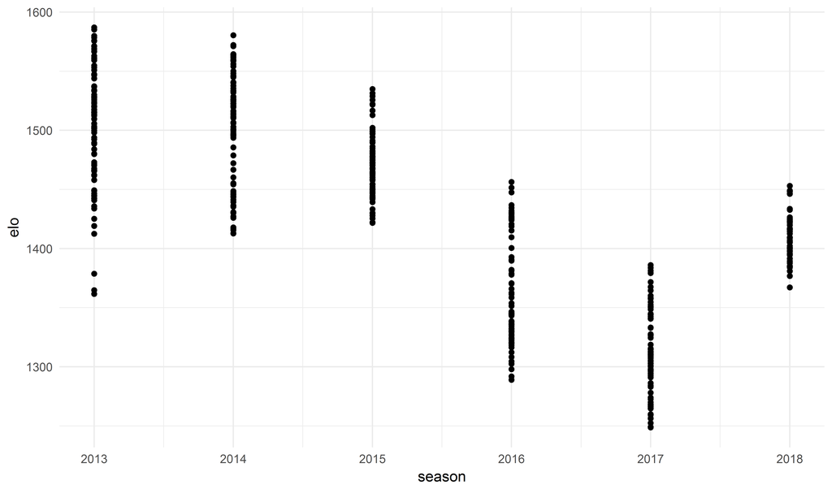

This plot takes a closer look at the history of the elo of the Brooklyn Nets.

```
## # A tibble: 67,757 x 4
##          date season  team      elo
##        <date>  <int> <chr>    <dbl>
##  1 1947-03-08   1947   WSC 1499.214
##  2 1947-03-11   1947   WSC 1503.921
##  3 1947-03-13   1947   WSC 1520.244
##  4 1947-03-15   1947   WSC 1523.039
##  5 1947-03-19   1947   WSC 1523.859
##  6 1947-03-22   1947   WSC 1507.998
##  7 1947-03-26   1947   WSC 1516.364
##  8 1947-03-29   1947   WSC 1518.725
##  9 1948-04-08   1948   BLB 1499.502
## 10 1948-04-13   1948   BLB 1499.832
## # ... with 67,747 more rows
```

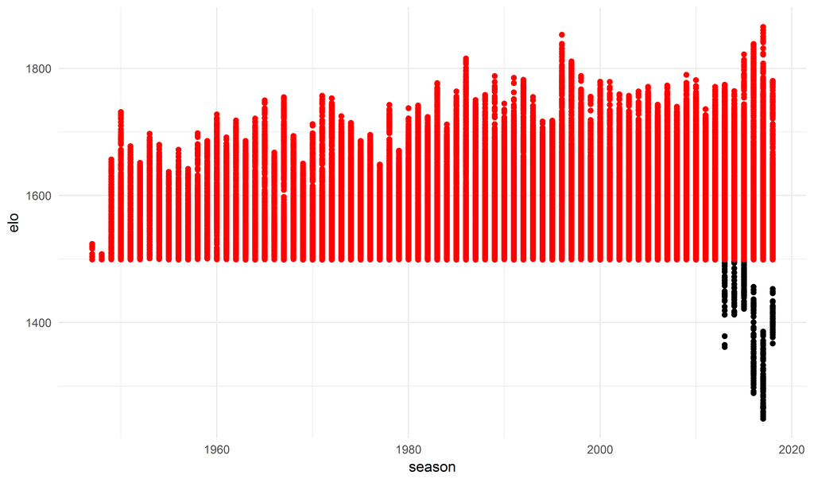

This graph shows the times the Nets(black) dipped below the nba average elo.

```
## # A tibble: 67,757 x 4
##          date season  team      elo
##        <date>  <int> <chr>    <dbl>
##  1 1947-03-08   1947   WSC 1499.214
##  2 1947-03-11   1947   WSC 1503.921
##  3 1947-03-13   1947   WSC 1520.244
##  4 1947-03-15   1947   WSC 1523.039
##  5 1947-03-19   1947   WSC 1523.859
##  6 1947-03-22   1947   WSC 1507.998
##  7 1947-03-26   1947   WSC 1516.364
##  8 1947-03-29   1947   WSC 1518.725
##  9 1948-04-08   1948   BLB 1499.502
## 10 1948-04-13   1948   BLB 1499.832
## # ... with 67,747 more rows
```

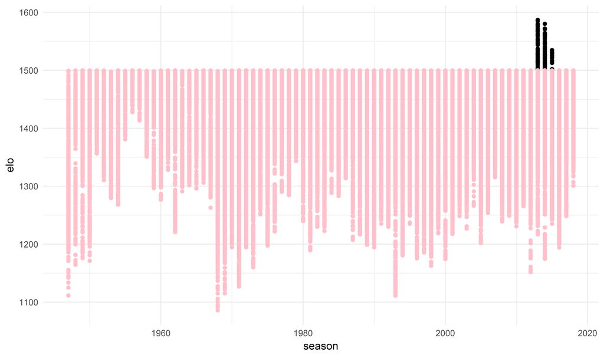

This graph shows all the times the Nets were above the league avg elo.

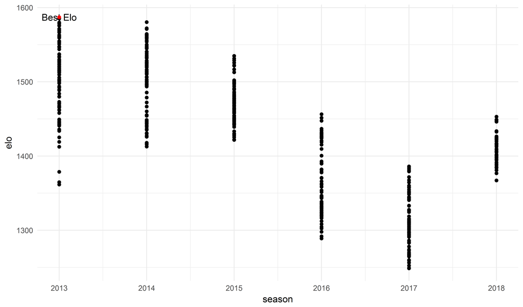

This plot shows the greatest elo experienced in the Nets breif history (1587.034). The point is highlighted in red and labeled. This season player Williams and Johnson were in their prime.